# Women’s BMI in Tanzania.

Patterns and Determinants from the 2015 DHS.

Ludovick L. Lopa

July 4th, 2025

## 1 Introduction

The Demographic and Health Survey (DHS) is a key source of reliable data on population health in developing countries. In Tanzania, seven DHS surveys have been conducted between 1991 and 2022, helping to track progress in health and living standards over time.<sup>1</sup> The main goal of DHS is to provide up-to-date information that supports evidence-based decision-making at national and international levels.

This brief draws on data from the 2015 Tanzania Demographic and Health Survey (DHS), focusing on a nationally representative sample of 13,266 women from all 30 regions— 25 in mainland Tanzania and 5 in Zanzibar.<sup>2</sup> The regions were grouped according to Tanzania’s nine geographic zones and further stratified into rural and urban areas to enable meaningful comparisons across different population groups.

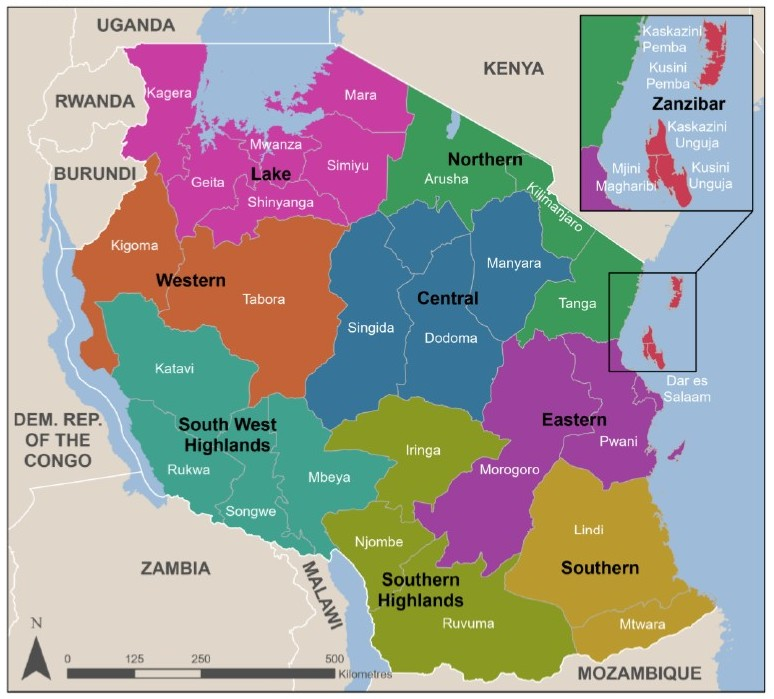

**Figure 1.** Regions of Tanzania (*Source: DHS 2022*).

The brief analyzes the patterns and determinants of elevated Body Mass Index (BMI) among women in Tanzania. BMI is a widely used measure of nutritional status and a key risk factor for non-communicable diseases. The World Health Organization (WHO) classifies BMI as follows: underweight (<18.5 kg/m²), normal weight (18.5–24.9 kg/m²), overweight (25.0–29.9 kg/m²), and obese (≥30.0 kg/m²).<sup>3</sup> By examining BMI trends, this brief offers critical insights into the physical health and nutritional well-being of Tanzanian women.

## 2 Objectives

This report has two main objectives:

- To describe the patterns of BMI among women in Tanzania.
- To identify key socio-demographic and related factors associated with variations in BMI.

## 3 Demographic Characteristics

**Table 1.** Demographic characteristics by place of residence.

| **Characteristic** | **Residence** **Rural** N = 7,009<sup>1</sup> | **Residence** **Urban** N = 1,476<sup>1</sup> | **p-value**<sup>2</sup> |  |
| --- | --- | --- | --- | --- |
| Age (years) | 28.0 (17.0) | 27.0 (16.0) |  | 0.005 |
| Weight (kg) | 53.6 (11.9) | 56.5 (15.8) | <0.001 |  |
| Height (cm) | 156.3 (8.4) | 156.2 (8.1) | 0.15 |  |
| Body Mass Index (BMI) | 21.9 (4.3) | 23.1 (5.9) | <0.001 |  |
| Haemoglobin Level (mg/dL) | 12.2 (2.3) | 12.2 (2.3) | 0.14 |  |
| Number of Deliveries (Parity) | 3.0 (4.0) | 2.0 (4.0) | <0.001 |  |
| Smokes Cigarettes | 19 (0.3%) | 6 (0.4%) | 0.4 |  |
| Ever Consumed Alcohol | 972 (14%) | 232 (16%) | 0.064 |  |
| Time to water source (minutes) | 30.0 (45.0) | 30.0 (50.0) | <0.001 |  |

<sup>1</sup> Median (IQR); n (%)  
<sup>2</sup> Welch Two Sample t-test; Fisher’s exact test; Pearson’s Chi-squared test

Figure 2 illustrates the distribution of the wealth index by residence— urban (left) versus rural (right). Women living in urban areas were three times more likely to fall in the richer or richest categories (89.8%) compared to their rural counterparts (30.6%). Women in rural areas were over eight times more likely to be in the poor or poorest wealth categories (44.8%) than those in urban settings (5.4%).

[interactive chart not shown]

Table 2 presents the highest educational attainment by place of residence. At least 81.4% of women in rural areas had primary education or higher, compared to 93.8% of women in urban areas.

**Table 2.** Educational attainment by place of residence.

| **Characteristic** | **Residence** **Rural** N = 9,121<sup>1</sup> | **Residence** **Urban** N = 4,145<sup>1</sup> | **p-value**<sup>2</sup> |  |
| --- | --- | --- | --- | --- |
| Highest education |  |  |  | <0.001 |
| No Education | 1,740 (19%) | 258 (6.2%) |  |  |
| Primary | 5,468 (60%) | 2,172 (52%) |  |  |
| Secondary | 1,880 (21%) | 1,607 (39%) |  |  |
| Higher | 33 (0.4%) | 108 (2.6%) |  |  |

<sup>1</sup> n (%)  
<sup>2</sup> Pearson’s Chi-squared test

## 4 Understanding the Determinants of BMI

### 4.1 BMI Distribution by Age

Increasing age was positively associated with higher mean BMI, with older participants exhibiting significantly higher average BMI compared to adolescents.

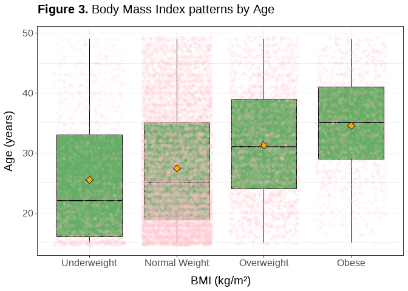

### 4.2 BMI Distribution by Level of Education

Higher educational attainment was associated with an increase in mean BMI. Individuals with no formal education had a mean BMI of 22.8kg/m² (SD = 4.0), which was notably lower than the 26.7kg/m² (SD = 6.0) observed among those with higher education

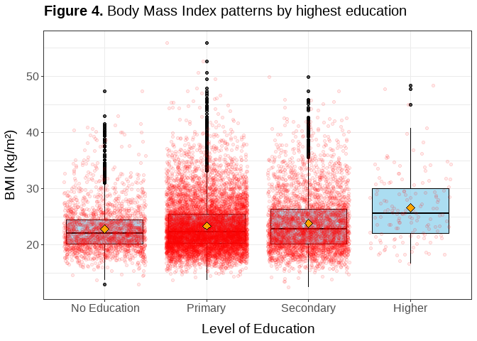

### 4.3 BMI Distribution by Wealth Index

In the 2015 DHS data, women’s BMI was influenced by wealth status. As wealth increased from the poorest to the richest groups, the proportion of overweight or obese women rose from 13% to 46%, while the proportion with normal weight dropped from 76% to 47%.

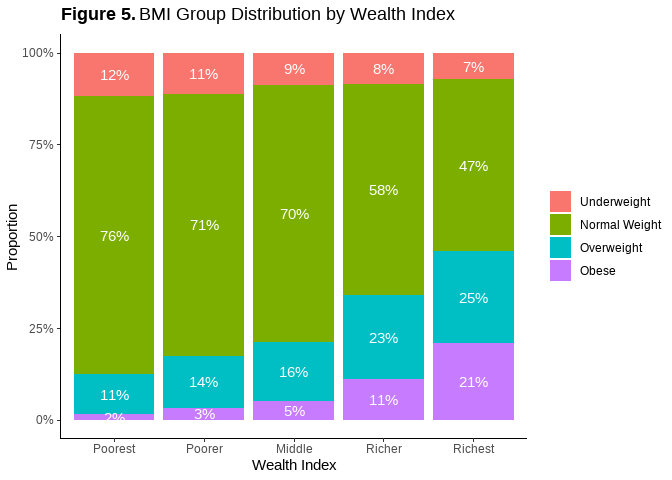

### 4.4 BMI Distribution by Parity

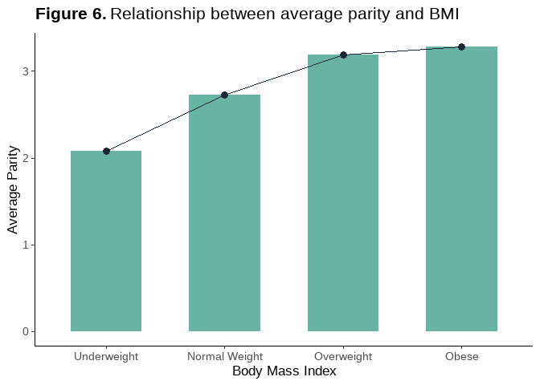

### 4.5 BMI Distribution by Alcohol Consumption

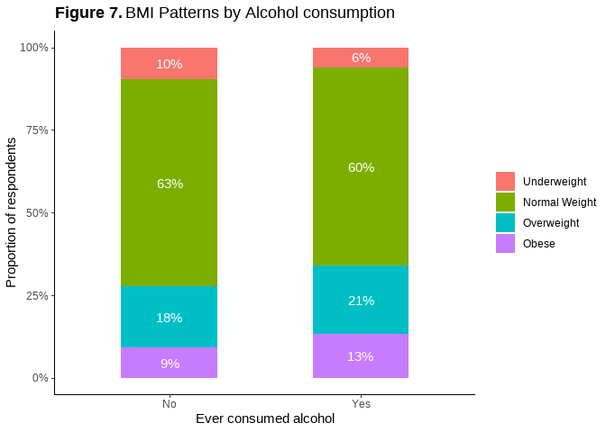

### 4.6 Geographical Variation in BMI Across Tanzanian Zones

The prevalence of overweight and obesity among women was highest in the Eastern (42%), Zanzibar (38%), and Northern (36%) zones. In contrast, the Lake zone had the lowest combined proportion at just 18%. This represents a twofold or greater difference between the highest and lowest zones.

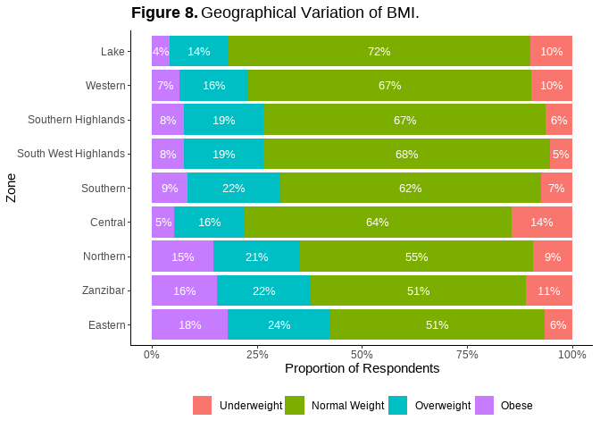

### 4.7 BMI Distribution by Occupational Group

Individuals working as professional/technical/managerial (56.3%), in clerical (47.4%), and service-related occupations—such as shopkeepers, waitstaff, drivers, and security guards (45.3%)—had the highest proportions of overweight and obesity. In contrast, those engaged in agricultural work, whether self-employed (19.9%) or employed (26.9%), had considerably lower rates. Interestingly, respondents who reported not working had the second-lowest proportion of overweight and obesity at 23.1%. However, the analysis showed that they had a mean age of 23 years, with a standard deviation of 8 years.

**Table 3.** BMI Distribution Within Each Occupation Group

|  | Underweight | Normal Weight | Overweight | Obese |
| --- | --- | --- | --- | --- |
| Agricultural - Employee | 28 (9.2%) | 195 (63.9%) | 53 (17.4%) | 29 (9.5%) |
| Agricultural - Self employed | 465 (8.5%) | 3911 (71.6%) | 839 (15.4%) | 245 (4.5%) |
| Clerical | 5 (6.4%) | 36 (46.2%) | 21 (26.9%) | 16 (20.5%) |
| Household & Domestic | 37 (5.9%) | 315 (50.5%) | 169 (27.1%) | 103 (16.5%) |
| Not Working | 443 (14%) | 1996 (62.9%) | 519 (16.3%) | 217 (6.8%) |
| Professional/Technical/Managerial | 25 (6.1%) | 155 (37.6%) | 121 (29.4%) | 111 (26.9%) |
| Services | 25 (5.6%) | 219 (49.1%) | 119 (26.7%) | 83 (18.6%) |
| Skilled Manual | 56 (10.1%) | 303 (54.8%) | 112 (20.3%) | 82 (14.8%) |
| Unskilled Manual | 120 (5.7%) | 1072 (50.9%) | 520 (24.7%) | 393 (18.7%) |

### 4.8 BMI Distributions by Marital Status

Respondents who had ever been married or lived with a partner were more likely to be overweight or obese than those who had never been in a union. About 35% of married participants had elevated BMI, compared to only 17% among those who had never lived with a partner.

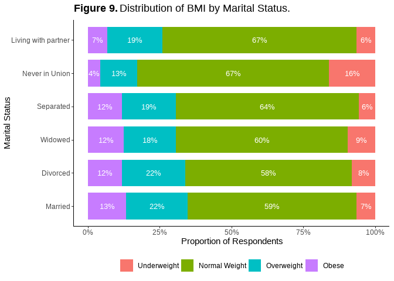

## 5 Discussion

### 5.1 Overweight and Obesity in Tanzania: A Growing Concern

Overweight and obesity are well-established risk factors for a range of non-communicable diseases (NCDs), including cardiovascular disease, type II diabetes, sleep apnea, and certain cancers such as breast and ovarian cancer. In recent decades, Tanzania has undergone rapid urbanization and lifestyle transitions that have significantly influenced the determinants of elevated body mass index (BMI) in both urban and rural populations—contributing to a growing epidemic of NCDs.<sup>4</sup>

Analysis of the 2015 Tanzania Demographic and Health Survey (DHS) women’s dataset reveals a positive association between elevated BMI and several sociodemographic and behavioral factors. These include higher levels of education, increased household wealth, higher parity (number of births), sedentary lifestyles, and alcohol consumption. When combined with increased caloric intake, these factors significantly heighten the risk of developing overweight and obesity.

Geographic disparities were also observed, with women residing in urban areas and in the Eastern, Northern, and Zanzibar zones exhibiting higher BMI levels. This may reflect a greater concentration of individuals exposed to the previously mentioned risk factors. Moreover, occupations characterized by low levels of physical exertion—more common in urban than rural settings—were associated with higher BMI, reinforcing the connection between sedentary work environments and weight gain.

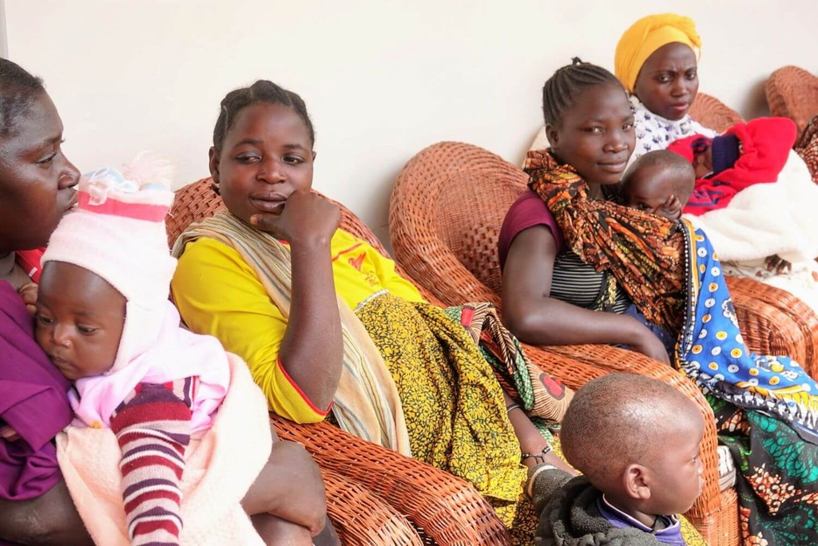

**Figure 10.** Motherhood is linked to a higher risk of elevated BMI (*Picture: Global Volunteers*).

Relationship status further influenced BMI outcomes. Women who were married, divorced, separated, or had previously cohabited with a partner were more likely to have elevated BMI. This may be partly attributable to higher age and parity among these groups, both of which are independent predictors of increased BMI. In contrast, women who had never been in a formal relationship were more likely to fall within lower BMI categories.

These findings underscore the need for targeted health promotion interventions that address behavioral risk factors and sedentary lifestyles, particularly among urban populations and individuals in low-activity occupations. Integrating awareness campaigns, workplace wellness programs, and community-based strategies could be critical in curbing the rising burden of obesity-related health risks in Tanzania.

### 5.2 Limitations of the Brief

- **Lack of Weighted Analysis.** The analysis did not apply sampling weights, which may limit the representativeness and generalizability of the findings to the national population.
- **Omission of Key Behavioral Variables.** Important determinants such as the amount of time allocated to physical activity and the quantity of alcohol consumed per week were not included in the analysis due to data limitations.

## 6 Conclusion

This brief highlights key sociodemographic and behavioral factors associated with elevated Body Mass Index (BMI) among women in Tanzania. Higher BMI was positively associated with increasing age, higher levels of education and household wealth, greater parity, alcohol consumption, sedentary occupations, urban residence, specific geographic zones such as the Eastern zone, and being in a marital or cohabiting relationship. These findings reflect the rising burden of non-communicable disease (NCD) risk factors in Tanzania, and the urgent need for targeted health promotion interventions.

## 7 References

- R Basics & Beyond Bootcamp 2025 Q2. https://thegraphcourses.org/courses/rbb-2025-q2/
- Tanzania Demographic and Health Survey and Malaria Indicator Survey 2022 Key Indicators Report. https://dhsprogram.com/pubs/pdf/PR144/PPR144.pdf
- Obesity : preventing and managing the global epidemic : report of a WHO Consultation on Obesity, Geneva, 3-5 June 1997. https://iris.who.int/handle/10665/63854
- Obesity epidemic in urban Tanzania: a public health calamity in an already overwhelmed and fragmented health system. https://bmcendocrdisord.biomedcentral.com/articles/10.1186/s12902-020-00631-3